# 36-315 Homework 10, Spring 2018

# Problem 4 (optional, ungraded)

(0 points)

This is an optional practice problem, designed to teach you how to (1) use `igraph` to compute simple statistics on a network dataset, (2) make plots with the `ggnetwork` package instead of `ggraph`, and (3) graph a directed network instead of Problem 1’s undirected network.

We encourage you to do this practice problem, especially if you are using a network dataset for your poster project, but no credit will be given for submitting it.

**Directed networks, `igraph`, and `ggnetwork`**

The `igraph` package makes network analysis easy! Install and load the `igraph` and `igraphdata` packages. Load the `UKfaculty` network into `R`:

```r
#install.packages("igraph")
#install.packages("igraphdata")
library(igraph)
library(igraphdata)
data(UKfaculty)
```

1. Try out some of the built-in functions in the `igraph` package in order to summarize the UK faculty network:
- How many nodes (“vertices”) are in the network? (Hint: use `vcount()`.)
- How many edges (“links”) are in the network? (Hint: use `ecount()`.)
2. Each of the node of this network is the personal friendship network of a faculty of a UK university. In order to get a vector of the node labels, you can use the function `V()`. Save this vector as `graph_node_label`.
3. The `igraph` package has some built-in functions for analyzing both the in-degree and out-degree of the nodes in the network. Use the `igraph` function `degree` to get:
- The in-degrees of all nodes. Save them as `in_degree_count`. (Hint: set the `mode` argument as `'in'` in the `degree` function)
- The out-degrees of all nodes. Save them as `out_degree_count`. (Hint: set the `mode` argument as `'out'` in the `degree` function)

Partial code is provided below.

```r
in_degree_count <- degree(UKfaculty, mode = "in")

# Also compute out_degree_count here
```

4. Create now a dataframe with the three vectors created above, containing the nodes labels, in-degrees, and out-degrees respectively. (You may need to `cbind()` the vectors together, then save the result as a data frame.) Create a scatterplot of the in-degrees versus the out-degrees and comment on whether there seems to be any relationship between the two.
5. Let’s actually visualize the network itself! Install and load the `ggnetwork` package. This package is decently new (you can read more about how to use it [in this article on the package](http://www.r-bloggers.com/ggnetwork-network-geometries-for-ggplot2/).

You’ll also need to install and load the `intergraph` package in order to use `igraph` objects with `ggnetwork`. Finally, depending on which version of `ggplot2`, `R`, and RStudio you’re running, you may need to update your packages to the latest versions that are on GitHub (see the first commented lines of code below).

Visualize the UK faculty network using the code below. Be sure to:

- Add a title
- Add a caption
- Remove the x- and y-axis labels
- Remove the x- and y-axis tick marks
- Adjust the `color` legend
- Adjust the `size` legend

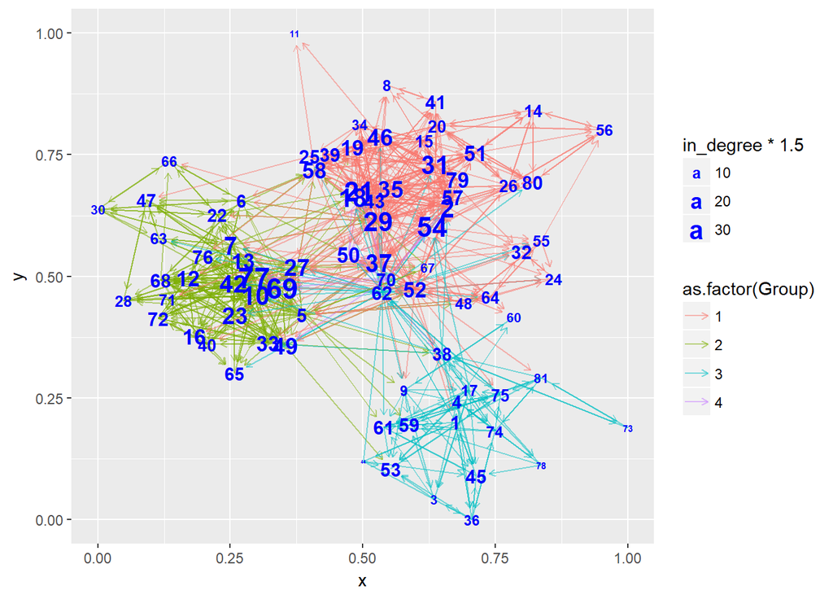

```r
## Run these only if install.packages() does not work for you
#devtools::install_github("briatte/ggnetwork")
#devtools::install_github("mbojan/intergraph")

library(ggnetwork)
library(intergraph)

uk_data <- fortify(UKfaculty)
uk_in_degrees <- in_degree_count[match(uk_data$vertex.names,
                                       1:length(in_degree_count))]
uk_data$in_degree <- uk_in_degrees
ggplot(uk_data,
       aes(x, y, xend = xend, yend = yend)) +
  geom_edges(arrow = arrow(length = unit(0.3, "lines")),
             aes(color = as.factor(Group)), alpha = 0.5) +
  geom_nodetext(aes(label = vertex.names, size = in_degree * 1.5),
                color = "blue", fontface = "bold")
```

6. Look at the network plot above:
- How many groups (“cliques”) do there appear to be?
- What does the size of the nodes correspond to?
- What does the color of the edges correspond to?
- Is the graph a directed or an undirected graph?